# R을 이용한 공공데이터 분석_제9장

## 3. hist() 함수

- 히스토그램(histogram, 도수분포표)을 그리는 그래프.
- barplot() 함수는 X축에 명목형 변수를 두고 변수의 빈도수를 그림으로 그리지만, hist()함수에서는 X축이 수치형 연속형 변수이야한다.

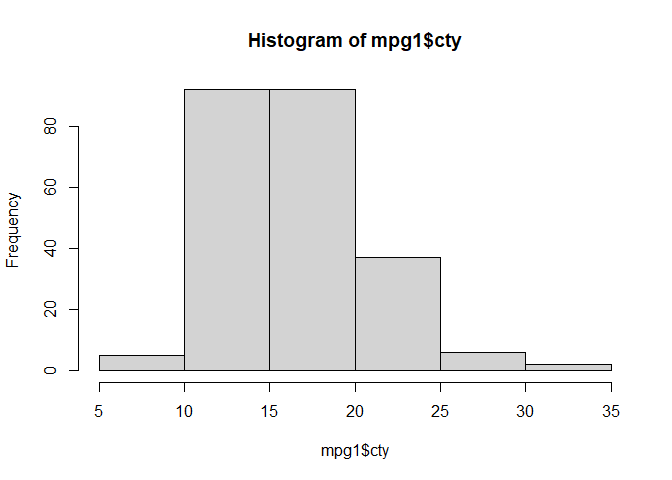

```r
# 6개 구간으로 구분
hist(mpg1$cty)
```

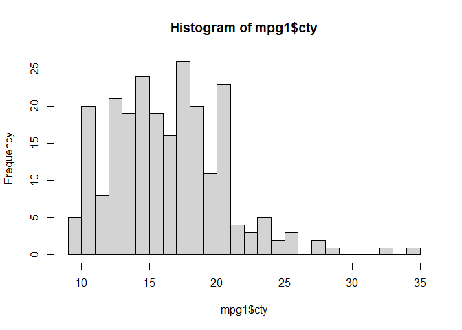

```r
# 지정한 20 구간으로 구분
hist(mpg1$cty,breaks = 20)
```

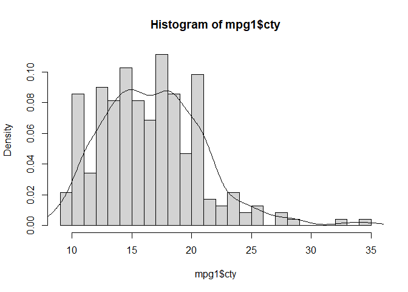

```r
# prob=T : 빈도수를 기준으로 확율밀도를 구해서 그래프를 그린다.
# y 축에 빈도수 대신 확률밀도가 표시.
hist(mpg1$cty,breaks = 20,prob=T)


hist(mpg1$cty,breaks = 20,prob=T)
lines(density(mpg1$cty))
```

[output not shown]

# 3단원 ggplot 그래프 (201p) 여기부터!!!

## 1. 기본개념

- ggplot2는 그래프를 한꺼번에 그리지 않고 전체 그림의 일부를 투명한 그림판에 나눠 그린 후에 그림판을 겹쳐서 완성한다.
- 그림한을 레이어(layer)라고 한다.

```r
# install.packages("ggplot2")
library(ggplot2)
```

## 2. 그래프 그리기

### 2.1. geom_point : 산점도 그리기

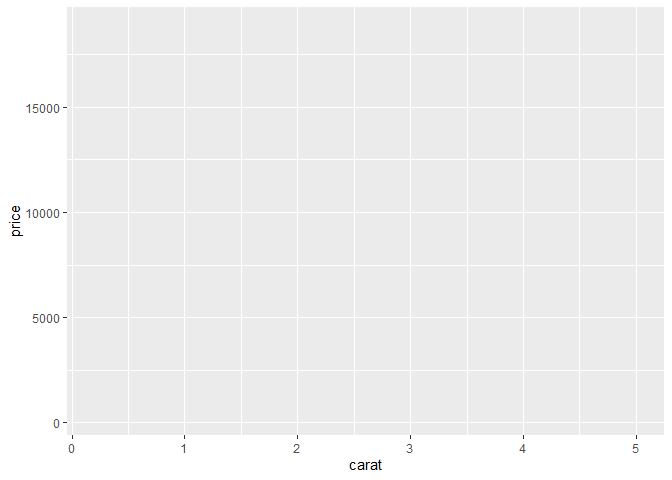

```r
diamonds<-ggplot2::diamonds # diamonds 데이터세트를 새 객체 diamonds에 입력

#Step 1. x축 y축 지정
ggplot(data=diamonds,aes(x=carat,y=price))
```

```r
#Step 2. geom_point()라는 산점도 그래프로 데이터를 표시
ggplot(data=diamonds,aes(x=carat,y=price)) +geom_point()
```

[output not shown]

### 2.2. 막대그래프 그리기

- 1 geom_bar() : ggplot2가 원자료에서 범주별 크기를 구해서 막대그래프 그리기

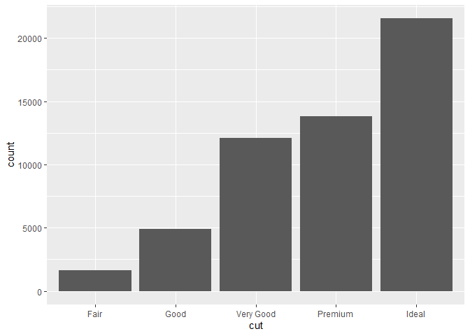

```r
# 방법 1. x축에 범주형 변수만 지정, ggplot2가 범주별 빈도수를 구해 막대 그래프로 표시
ggplot(diamonds,aes(x=cut))+geom_bar()
```

```r
table(diamonds$cut)
```

```
##
##      Fair      Good Very Good   Premium     Ideal
##      1610      4906     12082     13791     21551
```

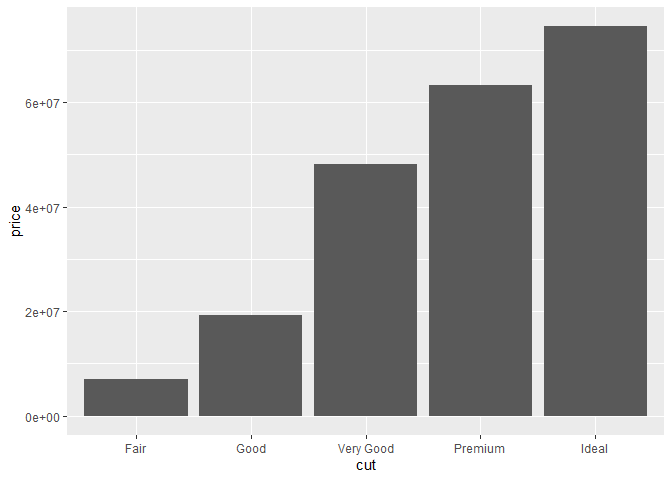

```r
# 방법 2. x축에 범주형 변수, y축에 연속형 변수
# 이때는 geom_bar()안에 stat = "identity"를 적어줘야함
ggplot(diamonds,aes(x=cut,y=price))+geom_bar(stat = "identity")
```

```r
library(dplyr)
# cut 범주별 평균 가격 구하기
cut_price <-diamonds %>%
  group_by(cut) %>% # cut 범주별 데이터 분류
  summarise(mean_price=mean(price)) #cut의 범주별 평균가격 구하기

cut_price  # cut의 범주별 평균가격
```

```
## # A tibble: 5 × 2
##   cut       mean_price
##   <ord>          <dbl>
## 1 Fair           4359.
## 2 Good           3929.
## 3 Very Good      3982.
## 4 Premium        4584.
## 5 Ideal          3458.
```

### 2.3. geom_histogram() : 히스토그램(도수분포표) 그리기

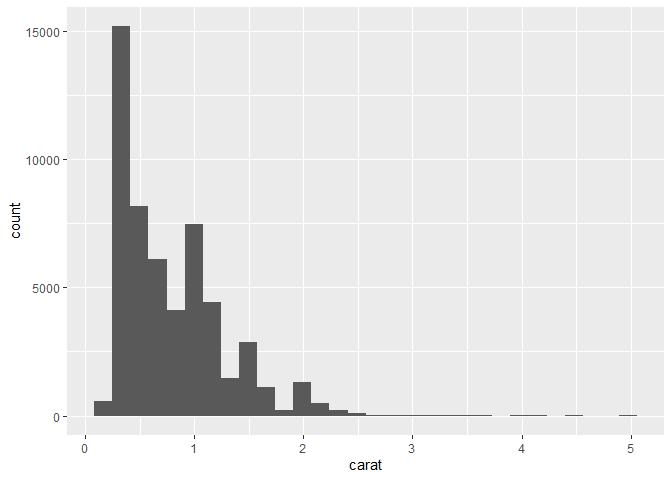

```r
ggplot(data = diamonds,aes(x=carat))+geom_histogram()
```

```r
range(diamonds$carat)
```

```
## [1] 0.20 5.01
```

```r
(5.01-.020)/30
```

```
## [1] 0.1663333
```

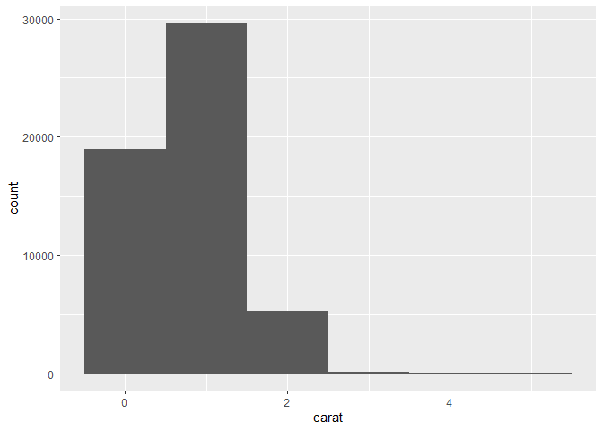

```r
ggplot(data=diamonds,aes(x=carat)) + geom_histogram(binwidth = 1)
```

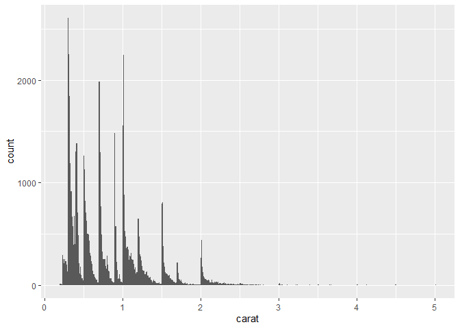

```r
ggplot(data=diamonds,aes(x=carat)) + geom_histogram(binwidth = 0.01)
```

### 2.4. geom_density() : 커널 밀도 곡선

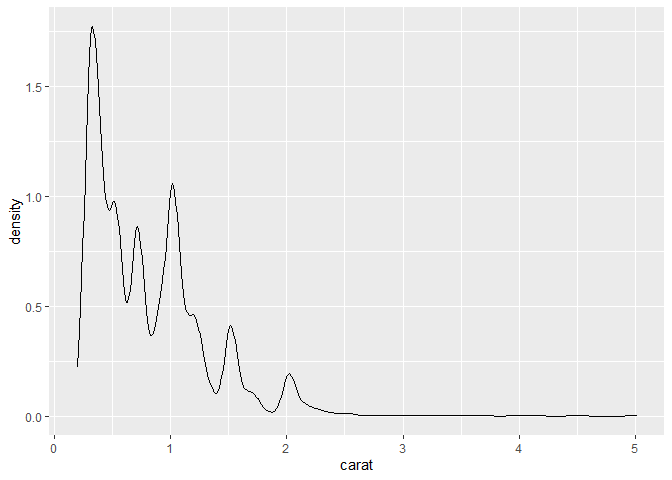

```r
ggplot(data=diamonds,aes(x=carat))+geom_density()
```

### 2.5. geom_boxplot() : 상자그림 그래프 그리기

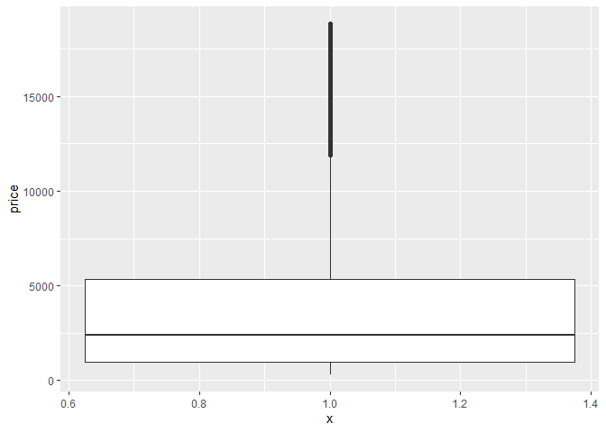

```r
ggplot(data=diamonds,aes(x=1,y=price)) +geom_boxplot()
```

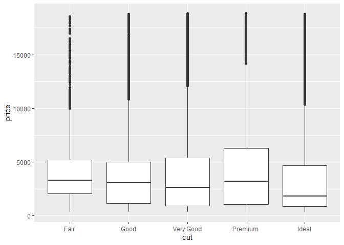

```r
ggplot(data = diamonds,aes(x=cut,y=price)) + geom_boxplot()
```

### 2.6. geom_line() : 선그래프 그리기

```r
str(cars)
```

```
## 'data.frame':    50 obs. of  2 variables:
##  $ speed: num  4 4 7 7 8 9 10 10 10 11 ...
##  $ dist : num  2 10 4 22 16 10 18 26 34 17 ...
```

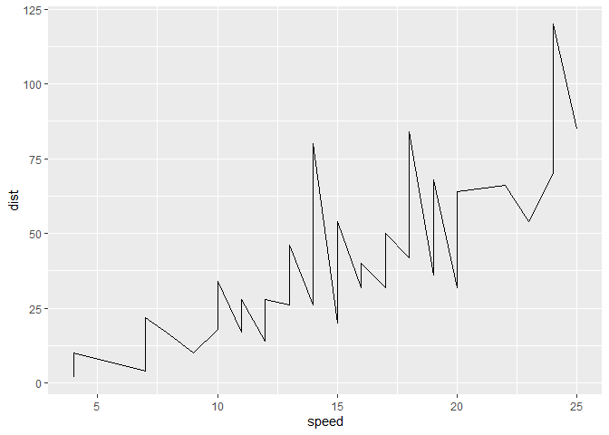

```r
ggplot(data = cars,aes(x=speed,y=dist)) + geom_line()
```

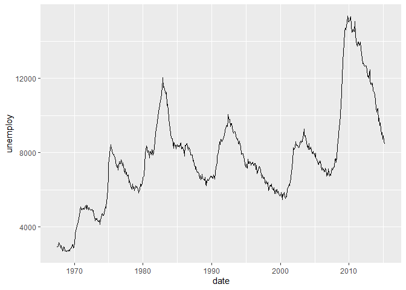

```r
# 실업자수 변화
ggplot(data = economics,aes(x=date,y=unemploy)) + geom_line()
```

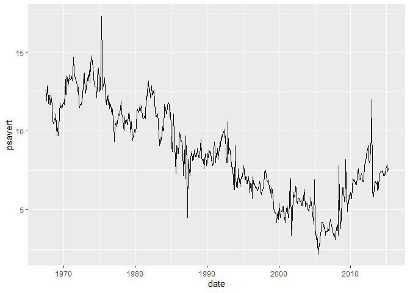

```r
# 개인저축률 변화
ggplot(data = economics,aes(x=date,y=psavert))+geom_line()
```

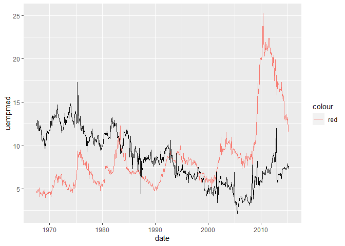

```r
# 두 개 데이터를 한 화면에 비교
ggplot()+
  geom_line(data=economics,aes(x=date,y=uempmed, color="red"))+
  geom_line(data = economics,aes(x=date, y=psavert))
```

# 4단원 ggplot() 함수를 정교하게 그리기 (215p)

## 1. col=, fill= : 1개의 그래프에 2개 변수를 반영하기

### 1.1. ‘col=’+geom_point() : 산점도에 변수를 추가해서 그리기

```r
ggplot(data = diamonds,aes(x=carat,y=price))+geom_point()
```

[output not shown]

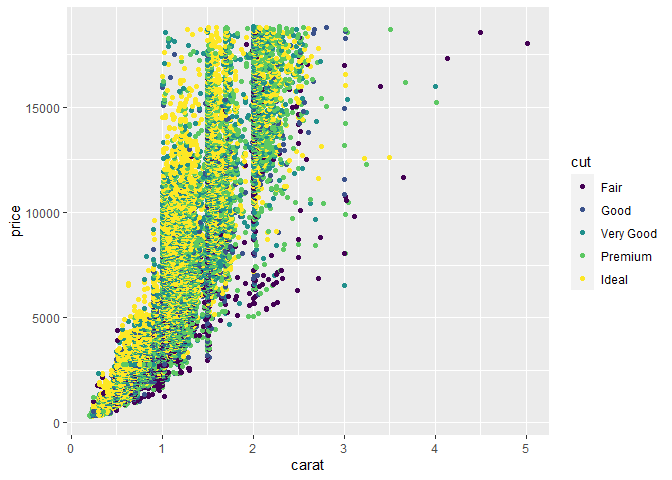

```r
ggplot(data = diamonds,aes(x=carat,y=price,col=cut)) + geom_point() #col(color)
```

### 1.2. ‘fill=’+geom_bar() : 막대그래프에 2개 범주 내용을 반영하기

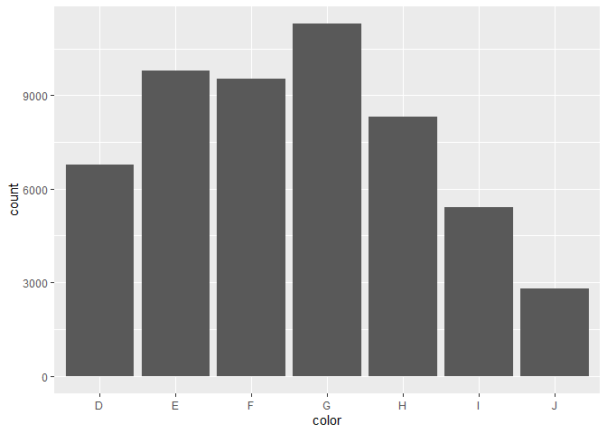

```r
ggplot(diamonds,aes(x = color)) +
  geom_bar()
```

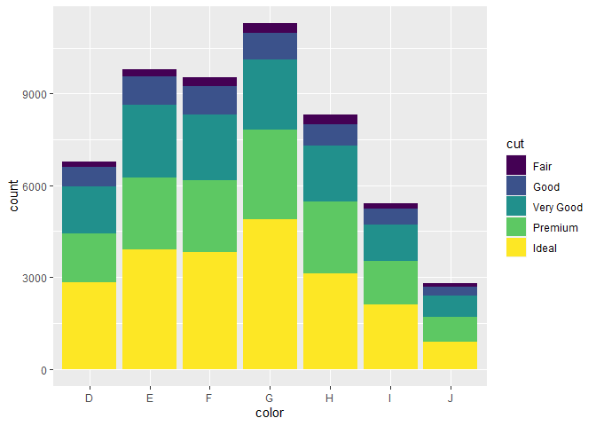

```r
ggplot(diamonds,aes(x = color, fill=cut)) +
  geom_bar()
```

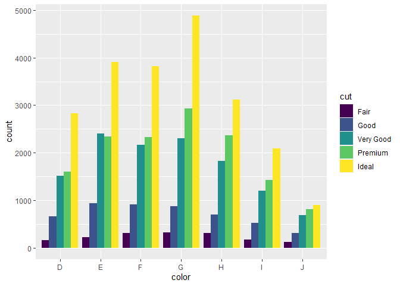

```r
ggplot(diamonds,aes(x = color, fill=cut)) +
  geom_bar(position = "dodge")
```

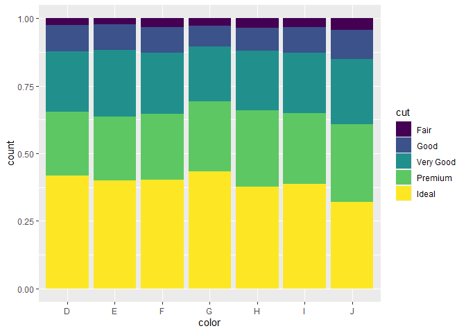

```r
ggplot(diamonds,aes(x = color, fill=cut)) +
  geom_bar(position = "fill")
```

### 1.3. ‘col=’+geom_line() : 선그래프에 2개 범주 내용을 반영하기

```r
leisure <-read.csv("data/leisure.csv")
str(leisure)
```

```
## 'data.frame':    200 obs. of  3 variables:
##  $ age    : int  2 2 3 3 4 4 5 5 6 6 ...
##  $ sex    : chr  "female" "male" "female" "male" ...
##  $ expense: num  25.8 21 30 16.3 25.7 ...
```

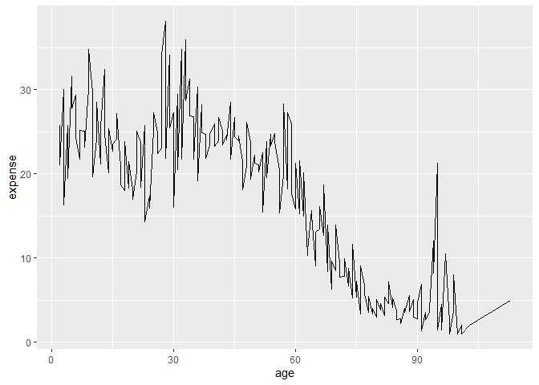

```r
ggplot(data=leisure,aes(x=age,y=expense))+geom_line()
```

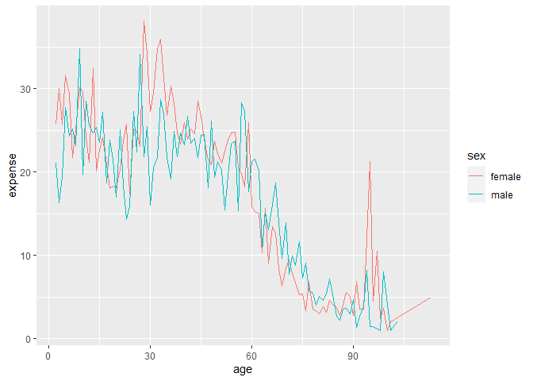

```r
# 색상 추가
ggplot(data=leisure,aes(x=age,y=expense,col=sex))+geom_line()
```

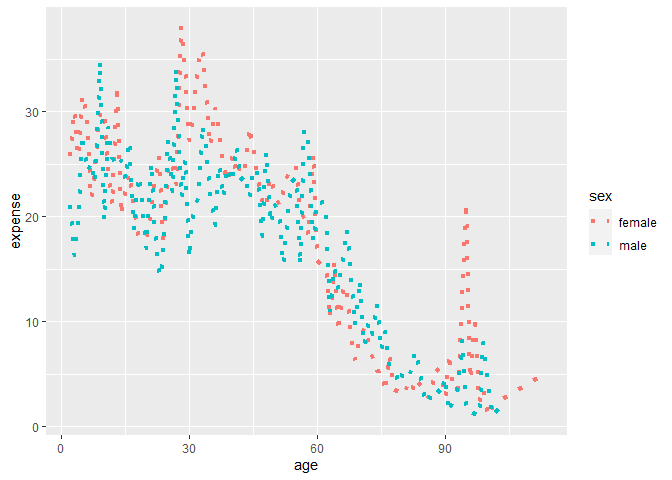

```r
# 그래프 사이즈, 라인 생김새 변경
ggplot(data=leisure,aes(x=age,y=expense,col=sex))+geom_line(size = 1.5, linetype = 3)
```

## 2. 막대그래프의 순서 변경

- 막대그래프에서 막대는 기본적으로 범주이름의 순서대로 정렬됨.
- 이런 경우 막대의 크기가 들쭉날쭉해서 분석 결과를 한눈에 알기 어려움.

### 2.1. reorder() : 크기 순으로 정렬

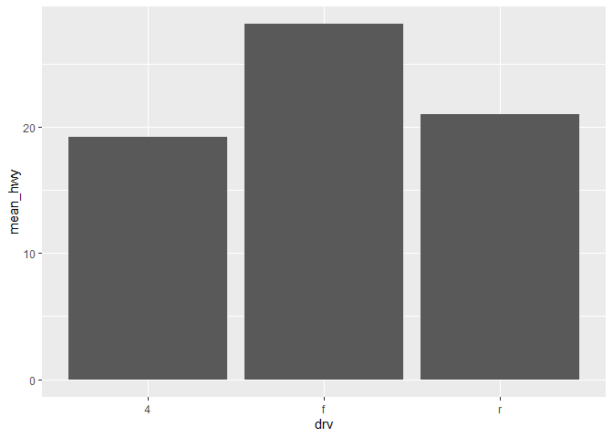

```r
library(dplyr)
mpg1<- read.csv("data/mpg1.csv",stringsAsFactors = F)

drv_hwy <-mpg1 %>%
  group_by(drv) %>%
  summarise(mean_hwy=mean(hwy))

# 기본그래프
ggplot(data = drv_hwy,aes(x=drv,y=mean_hwy))+geom_col()
```

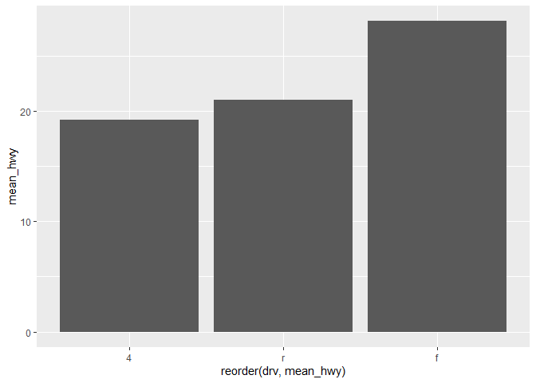

```r
# 오름차순
ggplot(data = drv_hwy,aes(x=reorder(drv,mean_hwy),y=mean_hwy)) + geom_col()
```

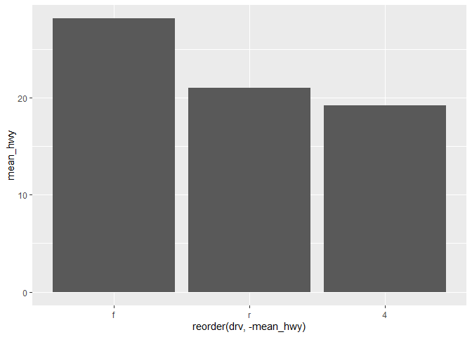

```r
# 내림차순
ggplot(data = drv_hwy,aes(x=reorder(drv,-mean_hwy),y=mean_hwy))+geom_col()
```

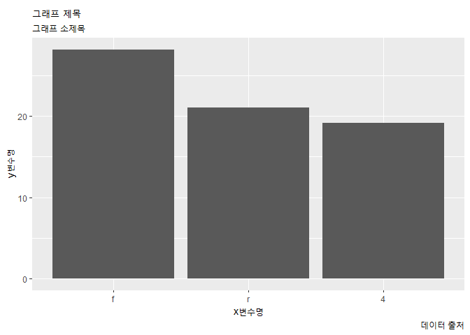

```r
# 옵션
ggplot(data = drv_hwy,aes(x=reorder(drv,-mean_hwy),
                          y=mean_hwy))+
  geom_col() +
  labs(
    title = "그래프 제목",
    subtitle = "그래프 소제목",
    x = "x변수명",
    y = "y변수명",
    caption = "데이터 출처"
  )
```

### 2.2. scale_x_discrete(limits=c()) : 그래프 순서를 직접 정하기 [SKIP]

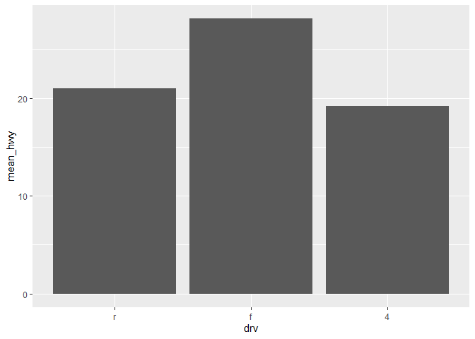

```r
# 'r,f,s' 순서대로 그리기
ggplot(data = drv_hwy,aes(x=drv, y=mean_hwy))+
  geom_col()+
  scale_x_discrete(limits=c("r", "f", "4"))
```

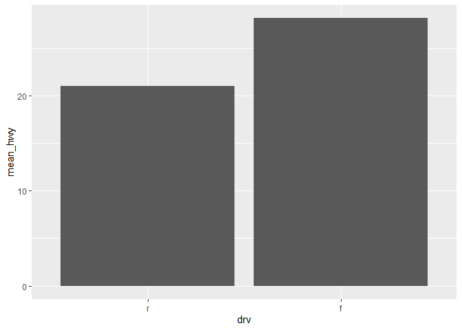

```r
# 일부만 선택해서 그래프 그리기.
ggplot(data = drv_hwy,aes(x=drv, y=mean_hwy))+
  geom_col()+
  scale_x_discrete(limits=c("r", "f"))
```

### 2.3. coord_flip() : 막대그래프를 90도 회전해서 수평으로 그리기 [SKIP]

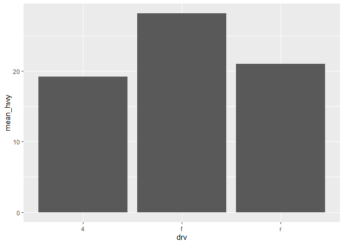

```r
# 기본 형태
ggplot(data = drv_hwy,aes(x=drv, y=mean_hwy)) + geom_col()
```

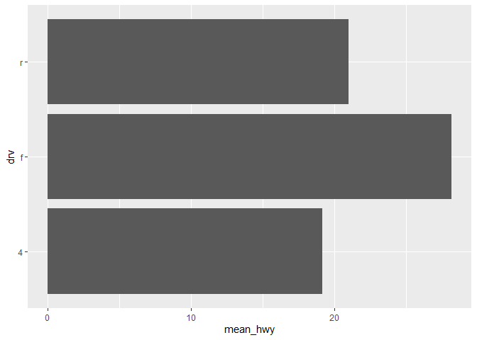

```r
# 수평으로 그리기
ggplot(data = drv_hwy,aes(x=drv, y=mean_hwy)) + geom_col() + coord_flip()
```

### 2.4. xlim(), ylim() : x축과 y축의 범위 지정하기 [SKIP]

- 그래프 모양은 전체 화면에 고르게 그려지는 것이 보기에 좋다.
- 데이터가 한 곳으로 몰려있지 않게 축의 범위를 지정할 수 있다.

```r
# 기본 형태
ggplot(data = diamonds,aes(x=carat, y=price)) + geom_point()
```

[output not shown]

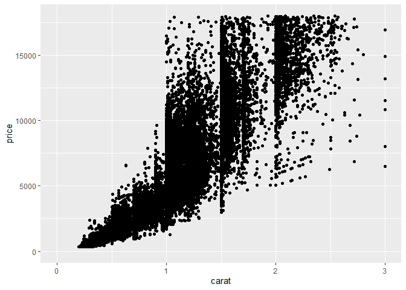

```r
# 범위 지정 했을 때
ggplot(data = diamonds,aes(x=carat, y=price)) + geom_point()+
  xlim(0,3) +
  ylim(0,18000)
```

### 2.5. ggtitle(), xlab(), ylab() : 그래프와 축에 이름 붙이기 [SKIP]

- 뒤에 ’5단원 > 3.옵션 > theme_classic() : 그래프 테마 바꾸는 법’이 더욱 디테일하게 관리 가능.

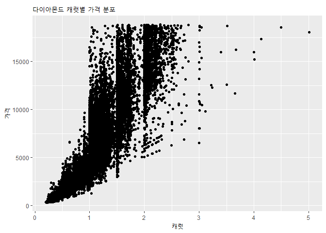

```r
ggplot(data = diamonds,aes(x=carat, y=price)) + geom_point()+
  ggtitle("다이아몬드 캐럿별 가격 분포")+
  xlab("캐럿")+
  ylab("가격")
```

# 5단원 ggplot2 강의 (책X)

## 1. 산점도 그래프 그리는 방법

- 산점도 : X축 수치형 연속형 데이터, y축 수치형 연속형 데이터
- 색상 값: [adobe colour](https://color.adobe.com/ko/create/color-wheel)
- [옵션 사용법](https://ggplot2.tidyverse.org/reference/aes_linetype_size_shape.html)
- 코드는 깃허브 R 파일 안에 있다.

```r
library(readxl)
library(ggplot2)
# 데이터 불러오기
who_disease <- read_xlsx("data/who_disease.xlsx")

# 기본 시각화
ggplot(who_disease,aes(x = year, y = cases)) + geom_point()
```

[output not shown]

```r
#aes는 축을 관리함함
# + 뒤에는 그래프 종류

?geom_point
```

```
## httpd 도움말 서버를 시작합니다 ... 완료
```

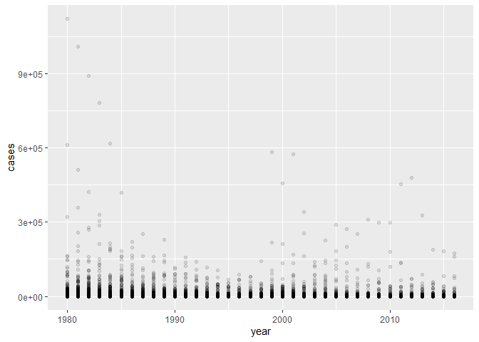

```r
# 옵션 1. alpha : 투명도 주기
ggplot(who_disease,aes(x = year, y = cases)) + geom_point(alpha=0.1)
```

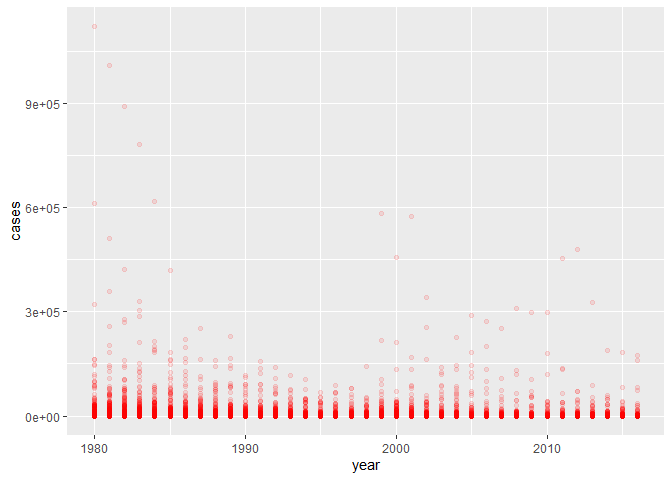

```r
# 옵션 2. colour : 색상 변화
ggplot(who_disease,aes(x = year, y = cases)) + geom_point(alpha=0.1, colour="red")
```

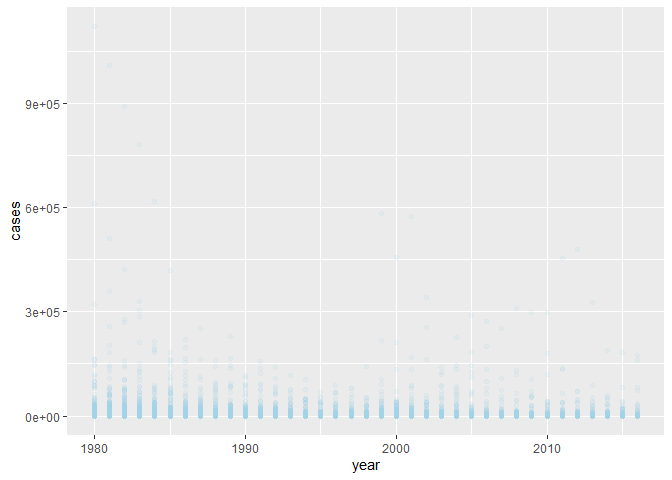

```r
ggplot(who_disease,aes(x = year, y = cases)) + geom_point(alpha=0.1, colour="#9FCFE3") #adode 가서 색상
```

```r
# 옵션 3. fill 색상을 채워 넣을 때
ggplot(who_disease,aes(x = year, y = cases)) + geom_point(fill="#BCF8FA")
```

[output not shown]

```r
# 옵션 4. group
ggplot(who_disease,aes(x = year, y = cases)) + geom_point()
```

[output not shown]

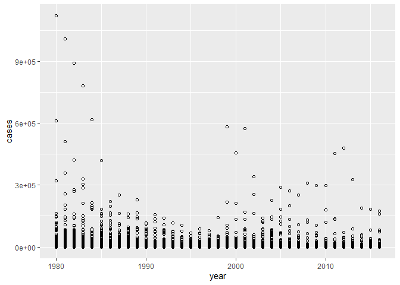

```r
# 옵션 5. shape : 모양
ggplot(who_disease,aes(x = year, y = cases)) + geom_point(shape=1)
```

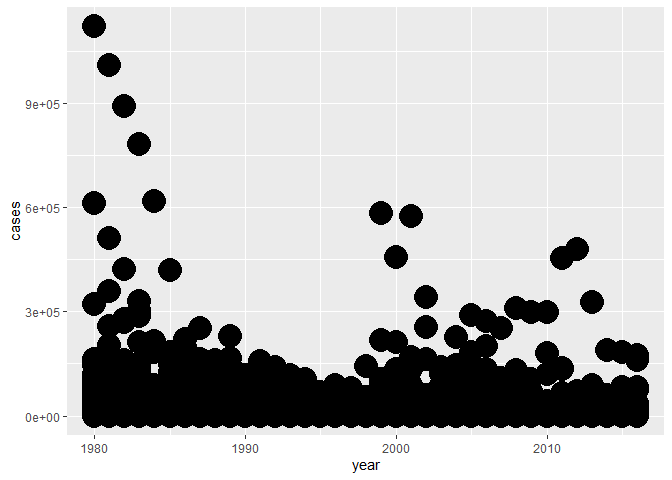

```r
# 옵션 6. size : 크기
ggplot(who_disease,aes(x = year, y = cases)) + geom_point(size=8)
```

```r
# 옵션 7. stroke
ggplot(who_disease,aes(x = year, y = cases)) + geom_point()
```

[output not shown]

### 1.1. colour 입력 위치 변경해보기

- 원래 : geom_point(colour=red_색상값)
- aes 안에 colour_옵션을 넣을 땐 ()에 컬럼명 넣기!
- ggplot(데이터, aes(x= 변수, y= 변수, colour=컬럼명, 옵션=컬럼명)) + geom_point()

```r
# colour 입력 위치 변경해보기
str(iris)
```

```
## 'data.frame':    150 obs. of  5 variables:
##  $ Sepal.Length: num  5.1 4.9 4.7 4.6 5 5.4 4.6 5 4.4 4.9 ...
##  $ Sepal.Width : num  3.5 3 3.2 3.1 3.6 3.9 3.4 3.4 2.9 3.1 ...
##  $ Petal.Length: num  1.4 1.4 1.3 1.5 1.4 1.7 1.4 1.5 1.4 1.5 ...
##  $ Petal.Width : num  0.2 0.2 0.2 0.2 0.2 0.4 0.3 0.2 0.2 0.1 ...
##  $ Species     : Factor w/ 3 levels "setosa","versicolor",..: 1 1 1 1 1 1 1 1 1 1 ...
```

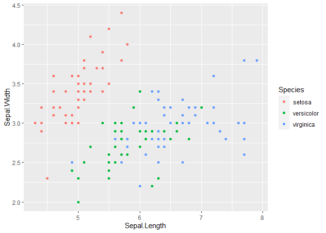

```r
ggplot(iris, aes(x= Sepal.Length,
                 y= Sepal.Width,
                 colour=Species)) +
  geom_point()
```

```r
# 컬럼별로 색상이 나뉜다.
```

## 2. 히스토그램 그리기

- 히스토그램은 데이터 분포가 어느 지역에 몰려있는지 확인해야한다.
- 질병데이터 region = AMR, year = 1980, disease= 백일해(pertussis)
- 그래프는 변수에 따라 달라진다.
- 그래프는 가공을 하고 그래프를 그려야한다.
- 참고 자료 : RStudio > Help > Cheat Sheets > data visualization with ggplot2

```r
# 데이터 가공
library(dplyr)
str(who_disease)
```

```
## tibble [43,262 × 6] (S3: tbl_df/tbl/data.frame)
##  $ region     : chr [1:43262] "EMR" "EUR" "AFR" "EUR" ...
##  $ countryCode: chr [1:43262] "AFG" "ALB" "DZA" "AND" ...
##  $ country    : chr [1:43262] "Afghanistan" "Albania" "Algeria" "Andorra" ...
##  $ disease    : chr [1:43262] "measles" "measles" "measles" "measles" ...
##  $ year       : num [1:43262] 2016 2016 2016 2016 2016 ...
##  $ cases      : num [1:43262] 638 17 41 0 53 0 0 2 99 27 ...
```

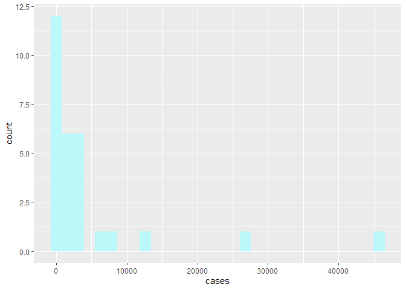

```r
data2 <-who_disease %>%
    filter(region =='AMR',
           year == 1980,
           disease == 'pertussis',
           cases >0) -> data2

# 가공된 데이터로 그래프 그리기
ggplot(data2,aes(x=cases)) +
  geom_histogram(fill="#BCF8FA")
```

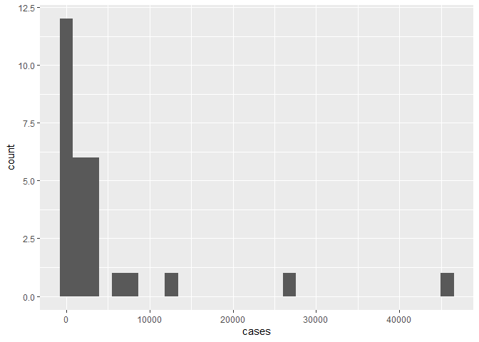

```r
ggplot(data2,aes(x=cases)) +
  geom_histogram()
```

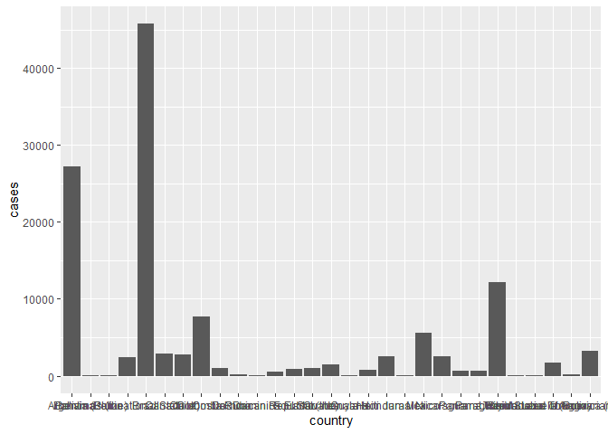

```r
ggplot(data2, aes(x=country, y= cases)) +
  geom_col()  # 글씨가 겹쳐서 하나도 안보임
```

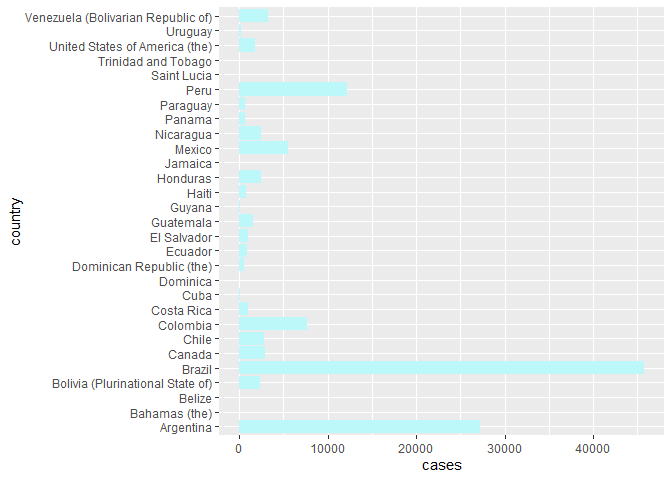

```r
ggplot(data2, aes(x=country, y= cases)) +
  geom_col(fill="#BCF8FA") +
  coord_flip() # 옵션, 글씨를 알아볼 수 있도록 글씨 방향을 돌려줌
```

## 3. 옵션

- [그래프 옵션, ggplot expansion package](https://exts.ggplot2.tidyverse.org/gallery/)

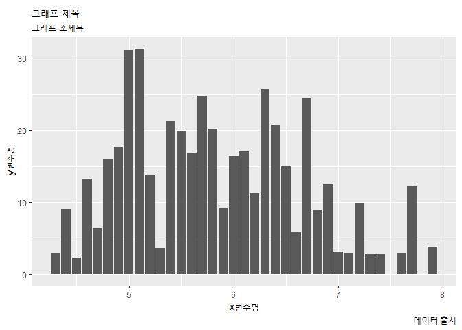

```r
# labs() : 그래프에 설명을 추가
library(ggplot2)
ggplot(data = iris,aes(x=Sepal.Length,
                          y=Sepal.Width))+
  geom_col() +
  labs(
    title = "그래프 제목",
    subtitle = "그래프 소제목",
    x = "x변수명",
    y = "y변수명",
    caption = "데이터 출처"
  )
```

```r
# scale_color_manual() : 컬럼별로 색상을 나눌 때, 지정된 색상을 내가 바꾸는 법
library(ggplot2)
str(iris)
```

```
## 'data.frame':    150 obs. of  5 variables:
##  $ Sepal.Length: num  5.1 4.9 4.7 4.6 5 5.4 4.6 5 4.4 4.9 ...
##  $ Sepal.Width : num  3.5 3 3.2 3.1 3.6 3.9 3.4 3.4 2.9 3.1 ...
##  $ Petal.Length: num  1.4 1.4 1.3 1.5 1.4 1.7 1.4 1.5 1.4 1.5 ...
##  $ Petal.Width : num  0.2 0.2 0.2 0.2 0.2 0.4 0.3 0.2 0.2 0.1 ...
##  $ Species     : Factor w/ 3 levels "setosa","versicolor",..: 1 1 1 1 1 1 1 1 1 1 ...
```

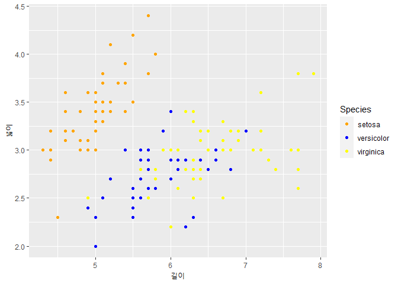

```r
ggplot(data = iris,aes(x=Sepal.Length, y=Sepal.Width, color=Species)) +
  geom_point() +
  labs(
    tile = "제목",
    x="길이",
    y="넓이") +
  scale_color_manual(
    labels = c("setosa", "versicolor", "virginica"),
    values = c("orange", "blue", "yellow"))
```

```r
# theme_classic() : 그래프 테마 바꾸는 법
library(ggplot2)
str(iris)
```

```
## 'data.frame':    150 obs. of  5 variables:
##  $ Sepal.Length: num  5.1 4.9 4.7 4.6 5 5.4 4.6 5 4.4 4.9 ...
##  $ Sepal.Width : num  3.5 3 3.2 3.1 3.6 3.9 3.4 3.4 2.9 3.1 ...
##  $ Petal.Length: num  1.4 1.4 1.3 1.5 1.4 1.7 1.4 1.5 1.4 1.5 ...
##  $ Petal.Width : num  0.2 0.2 0.2 0.2 0.2 0.4 0.3 0.2 0.2 0.1 ...
##  $ Species     : Factor w/ 3 levels "setosa","versicolor",..: 1 1 1 1 1 1 1 1 1 1 ...
```

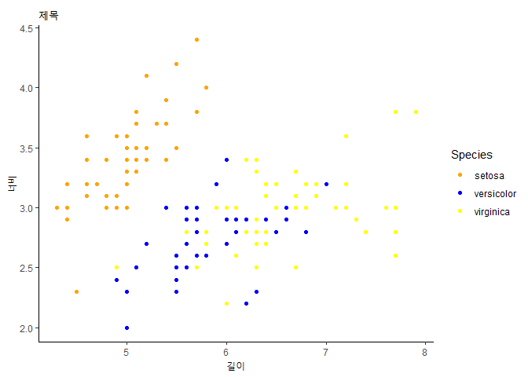

```r
ggplot(iris, aes(x = Sepal.Length, y = Sepal.Width, colour = Species)) +
  geom_point() +
  labs(
    title = "제목",
    x = "길이",
    y = "너비"
  ) +
  scale_color_manual(
    labels = c("setosa", "versicolor", "virginica"),
    values = c("orange", "blue",       "yellow")
  ) +
  theme_classic()
```